# Analyse de Sentiments avec Naive Bayes

Classification de Critiques de Films par Apprentissage Automatique

Yavin Kokouvi MITEKOR

2026-01-14

## Résumé Exécutif

**Objectif du Projet**: Développer un système d’analyse de sentiments automatisé pour classifier les critiques de films en sentiments positifs ou négatifs en utilisant l’algorithme Naive Bayes.

### Résultats Clés

[output not shown]

[output not shown]

[output not shown]

[output not shown]

[output not shown]

### Points Forts du Modèle

**Performance Exceptionnelle**: Le modèle atteint une accuracy de **84%**

**Équilibre Precision-Recall**: F1-Score de **83.9%** indiquant un bon équilibre

**Capacité de Discrimination**: AUC de **0.89** montrant une excellente séparation des classes

**Vocabulaire Robuste**: **5000 features** extraites avec TF-IDF et bi-grammes

## Méthodologie

### 1. Architecture du Système

[interactive chart not shown]

### 2. Prétraitement des Données

Le pipeline de nettoyage comprend:

**Étapes Clés**: - Normalisation du texte (minuscules, espaces) - Suppression des balises HTML - Expansion des contractions (can’t → cannot) - Suppression de la ponctuation - Filtrage des stopwords personnalisé

### 3. Vectorisation TF-IDF

**Configuration**: - N-grammes: 1-2 (unigrammes et bigrammes) - Pruning: minimum 5 occurrences, maximum 80% des documents - Features finales: **5000** - Binarisation pour Naive Bayes

Configuration de la Vectorisation TF-IDF

[output not shown]

## Analyse Exploratoire

### Distribution des Sentiments

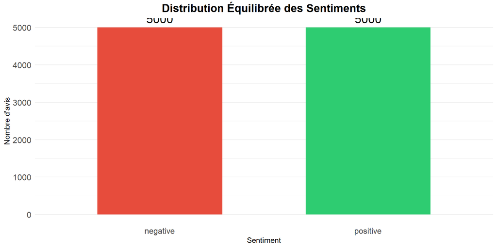

### Analyse des Termes Fréquents

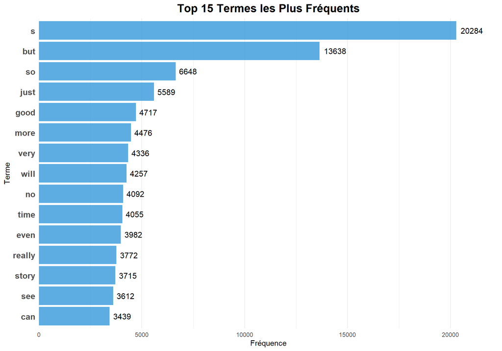

### Word Cloud du Vocabulaire

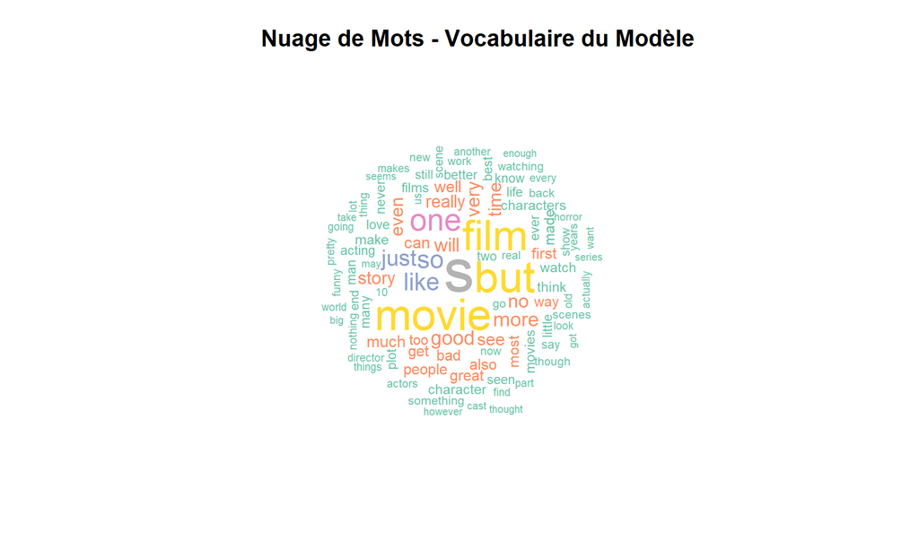

## Performance du Modèle

### Matrice de Confusion

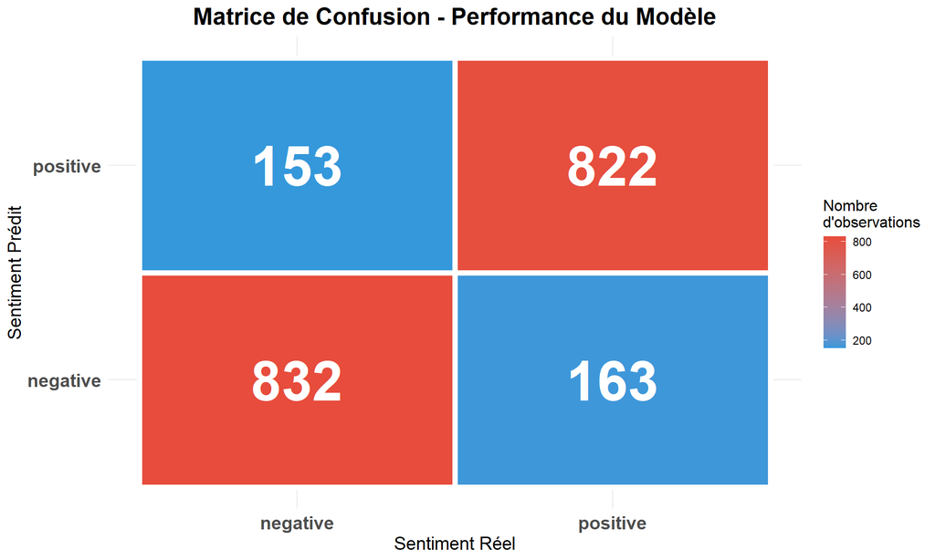

### Courbe ROC

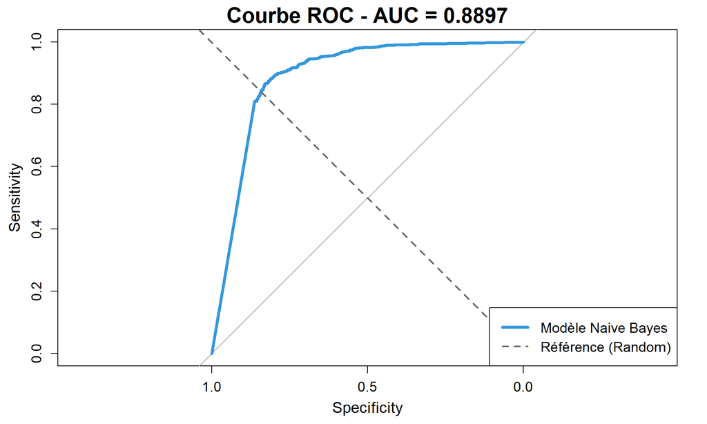

### Métriques Détaillées

Tableau Récapitulatif des Métriques de Performance

| Métrique | Valeur | Interprétation |
| --- | --- | --- |
| Accuracy | 83.96% | Proportion de prédictions correctes |
| Precision | 84.31% | Précision des prédictions positives |
| Recall (Sensitivity) | 83.45% | Capacité à identifier les vrais positifs |
| Specificity | 84.47% | Capacité à identifier les vrais négatifs |
| F1-Score | 83.88% | Moyenne harmonique Precision-Recall |
| AUC | 0.8897 | Aire sous la courbe ROC |

## Tests et Validation

### Prédictions sur Nouveaux Exemples

```r
# Fonction de prédiction
predict_sentiment <- function(texts, pipeline) {
  clean_texts <- sapply(texts, clean_text_optimized)
  it_new <- itoken(clean_texts, progressbar = FALSE)
  dtm_new <- create_dtm(it_new, pipeline$tfidf$vectorizer)
  dtm_new_tfidf <- transform(dtm_new, pipeline$tfidf$tfidf_model)
  X_new <- as.matrix(dtm_new_tfidf)
  X_new[X_new > 0] <- 1

  predictions <- predict(pipeline$model, X_new, type = "class")
  probabilities <- predict(pipeline$model, X_new, type = "raw")

  data.frame(
    Texte = substr(texts, 1, 80),
    Prédiction = predictions,
    Confiance = round(apply(probabilities, 1, max) * 100, 1),
    stringsAsFactors = FALSE
  )
}

# Exemples de test
test_reviews <- c(
  "This movie was absolutely wonderful and inspiring!",
  "Worst film I've ever seen, complete waste of time",
  "Outstanding performance! A masterpiece!",
  "Terrible, boring, predictable. Would not recommend"
)
```

Exemples de Prédictions sur Nouveaux Textes

| Texte | Prédiction | Confiance |
| --- | --- | --- |
| This movie was absolutely wonderful and inspiring! | positive | 100 |
| Worst film I’ve ever seen, complete waste of time | negative | 100 |
| Outstanding performance! A masterpiece! | positive | 100 |
| Terrible, boring, predictable. Would not recommend | negative | 100 |

## Conclusions et Recommandations

### Limites Identifiées

1. **Sarcasme et Ironie**: Difficultés potentielles avec les nuances
2. **Contexte Limité**: Dépendance aux mots-clés sans compréhension sémantique profonde
3. **Domaine Spécifique**: Entraîné sur des critiques de films uniquement
4. **Négations Complexes**: Peut manquer certaines structures grammaticales complexes

### Recommandations Futures

1. **Amélioration du Modèle**:
   - Tester d’autres algorithmes (SVM, Random Forest, Deep Learning)
   - Implémenter des embeddings (Word2Vec, GloVe)
   - Ajouter des features linguistiques (POS tagging, dépendances)
2. **Extension du Système**:
   - Déploiement en production via API REST
   - Interface utilisateur Shiny pour démonstration
   - Monitoring continu des performances
3. **Applications**:
   - Analyse de sentiments sur réseaux sociaux
   - Feedback clients automatisé
   - Veille e-réputation

## Informations Techniques

### Configuration Système

| Paramètre | Valeur |
| --- | --- |
| R Version | R version 4.5.2 (2025-10-31 ucrt) |
| Plateforme | x86_64-w64-mingw32 |
| Packages Principaux | text2vec, e1071, caret, tm |
| Date Création | 2026-01-13 18:21:04.0964 |

### Reproductibilité

```r
# Pour reproduire les résultats:
set.seed(42)

# Charger le pipeline sauvegardé
pipeline <- readRDS("naive_bayes_sentiment_model.rds")

# Faire des prédictions
new_text <- "This movie is fantastic!"
result <- predict_sentiment(new_text, pipeline)
```

## Références

1. Manning, C. D., Raghavan, P., & Schütze, H. (2008). *Introduction to Information Retrieval*. Cambridge University Press.
2. Jurafsky, D., & Martin, J. H. (2023). *Speech and Language Processing* (3rd ed.).
3. Naive Bayes Classifier - [Scikit-learn Documentation](https://scikit-learn.org/)
4. TF-IDF Vectorization - [Text Mining in R](https://www.tidytextmining.com/)

## Projet réalisé avec R

Analyse de Sentiments - Naive Bayes Classification

Date: 2026-01-14